# Exploratory Data Analysis of White Wine Quality

#### **Overview**:

This tidy data set contains 4,898 white wines with 11 variables on quantifying the chemical properties of each wine. At least 3 wine experts rated the quality of each wine, providing a rating between 0 (very bad) and 10 (very excellent).

#### **Question**:

The scope of this analysis is to analyze Which chemical properties influence the quality of white wines?

#### **Variable description**:

1. **Fixed acidity**: most acids involved with wine or fixed or nonvolatile (do not evaporate readily)
2. **Volatile acidity**: the amount of acetic acid in wine, which at too high of levels can lead to an unpleasant, vinegar taste
3. **Citric acid**: found in small quantities, citric acid can add ‘freshness’ and flavor to wines
4. **Residual sugar**: the amount of sugar remaining after fermentation stops, it’s rare to find wines with less than 1 gram/liter and wines with greater than 45 grams/liter are considered sweet
5. **Chlorides**: the amount of salt in the wine
6. **Free sulfur dioxide**: the free form of SO2 exists in equilibrium between molecular SO2 (as a dissolved gas) and bisulfite ion; it prevents microbial growth and the oxidation of wine
7. **Total sulfur dioxide**: amount of free and bound forms of S02; in low concentrations, SO2 is mostly undetectable in wine, but at free SO2 concentrations over 50 ppm, SO2 becomes evident in the nose and taste of wine
8. **Density**: the density of water is close to that of water depending on the percent alcohol and sugar content
9. **pH**: describes how acidic or basic a wine is on a scale from 0 (very acidic) to 14 (very basic); most wines are between 3-4 on the pH scale
10. **Sulphates**: a wine additive which can contribute to sulfur dioxide gas (S02) levels, wich acts as an antimicrobial and antioxidant
11. **Alcohol**: the percent alcohol content of the wine
12. **Quality**: output variable (based on sensory data, score between 0 and 10)

#### **Summary of the Data Set**

```r
wine <- read.csv('wineQualityWhites.csv')
dim (wine)
```

```
## [1] 4898   12
```

```r
str (wine)
```

```
## 'data.frame':    4898 obs. of  12 variables:
##  $ fixed.acidity       : num  7 6.3 8.1 7.2 7.2 8.1 6.2 7 6.3 8.1 ...
##  $ volatile.acidity    : num  0.27 0.3 0.28 0.23 0.23 0.28 0.32 0.27 0.3 0.22 ...
##  $ citric.acid         : num  0.36 0.34 0.4 0.32 0.32 0.4 0.16 0.36 0.34 0.43 ...
##  $ residual.sugar      : num  20.7 1.6 6.9 8.5 8.5 6.9 7 20.7 1.6 1.5 ...
##  $ chlorides           : num  0.045 0.049 0.05 0.058 0.058 0.05 0.045 0.045 0.049 0.044 ...
##  $ free.sulfur.dioxide : num  45 14 30 47 47 30 30 45 14 28 ...
##  $ total.sulfur.dioxide: num  170 132 97 186 186 97 136 170 132 129 ...
##  $ density             : num  1.001 0.994 0.995 0.996 0.996 ...
##  $ pH                  : num  3 3.3 3.26 3.19 3.19 3.26 3.18 3 3.3 3.22 ...
##  $ sulphates           : num  0.45 0.49 0.44 0.4 0.4 0.44 0.47 0.45 0.49 0.45 ...
##  $ alcohol             : num  8.8 9.5 10.1 9.9 9.9 10.1 9.6 8.8 9.5 11 ...
##  $ quality             : int  6 6 6 6 6 6 6 6 6 6 ...
```

```r
names (wine)
```

```
##  [1] "fixed.acidity"        "volatile.acidity"     "citric.acid"
##  [4] "residual.sugar"       "chlorides"            "free.sulfur.dioxide"
##  [7] "total.sulfur.dioxide" "density"              "pH"
## [10] "sulphates"            "alcohol"              "quality"
```

```r
wine$quality.bucket <- cut(wine$quality, c(2, 5, 6, 9))
summary(wine$quality.bucket)
```

```
## (2,5] (5,6] (6,9]
##  1640  2198  1060
```

```r
summary(wine)
```

```
##  fixed.acidity    volatile.acidity  citric.acid     residual.sugar
##  Min.   : 3.800   Min.   :0.0800   Min.   :0.0000   Min.   : 0.600
##  1st Qu.: 6.300   1st Qu.:0.2100   1st Qu.:0.2700   1st Qu.: 1.700
##  Median : 6.800   Median :0.2600   Median :0.3200   Median : 5.200
##  Mean   : 6.855   Mean   :0.2782   Mean   :0.3342   Mean   : 6.391
##  3rd Qu.: 7.300   3rd Qu.:0.3200   3rd Qu.:0.3900   3rd Qu.: 9.900
##  Max.   :14.200   Max.   :1.1000   Max.   :1.6600   Max.   :65.800
##    chlorides       free.sulfur.dioxide total.sulfur.dioxide
##  Min.   :0.00900   Min.   :  2.00      Min.   :  9.0
##  1st Qu.:0.03600   1st Qu.: 23.00      1st Qu.:108.0
##  Median :0.04300   Median : 34.00      Median :134.0
##  Mean   :0.04577   Mean   : 35.31      Mean   :138.4
##  3rd Qu.:0.05000   3rd Qu.: 46.00      3rd Qu.:167.0
##  Max.   :0.34600   Max.   :289.00      Max.   :440.0
##     density             pH          sulphates         alcohol
##  Min.   :0.9871   Min.   :2.720   Min.   :0.2200   Min.   : 8.00
##  1st Qu.:0.9917   1st Qu.:3.090   1st Qu.:0.4100   1st Qu.: 9.50
##  Median :0.9937   Median :3.180   Median :0.4700   Median :10.40
##  Mean   :0.9940   Mean   :3.188   Mean   :0.4898   Mean   :10.51
##  3rd Qu.:0.9961   3rd Qu.:3.280   3rd Qu.:0.5500   3rd Qu.:11.40
##  Max.   :1.0390   Max.   :3.820   Max.   :1.0800   Max.   :14.20
##     quality      quality.bucket
##  Min.   :3.000   (2,5]:1640
##  1st Qu.:5.000   (5,6]:2198
##  Median :6.000   (6,9]:1060
##  Mean   :5.878
##  3rd Qu.:6.000
##  Max.   :9.000
```

##### Instead analyzing the quality on all levels, I created a new variables and cut the quality into 3 range.

#### **Variable Distibution**

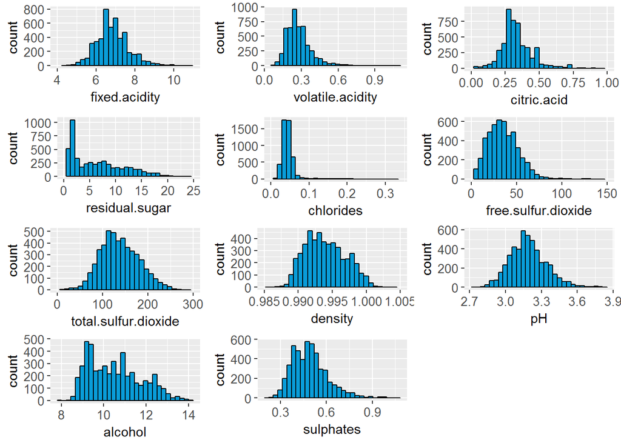

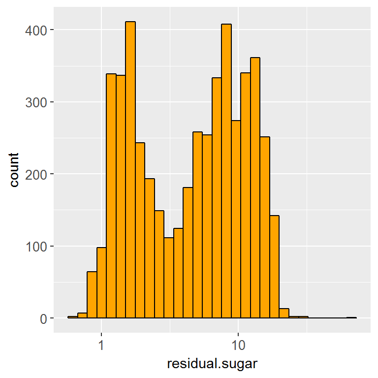

##### After we transformed the Residual.sugar distribtuion, this visualization identifies a bi-modal distribution of sugar.

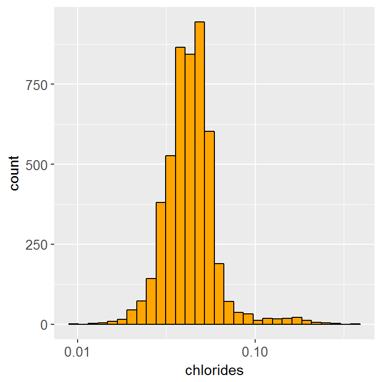

##### After we transformed the chlorides distribtuion, this visualization identifies a normal distribution.

#### **Correclations Analysis**

```
##                              [,1]
## fixed.acidity        -0.113662831
## volatile.acidity     -0.194722969
## citric.acid          -0.009209091
## residual.sugar       -0.097576829
## chlorides            -0.209934411
## free.sulfur.dioxide   0.008158067
## total.sulfur.dioxide -0.174737218
## density              -0.307123313
## pH                    0.099427246
## sulphates             0.053677877
## alcohol               0.435574715
## quality               1.000000000
```

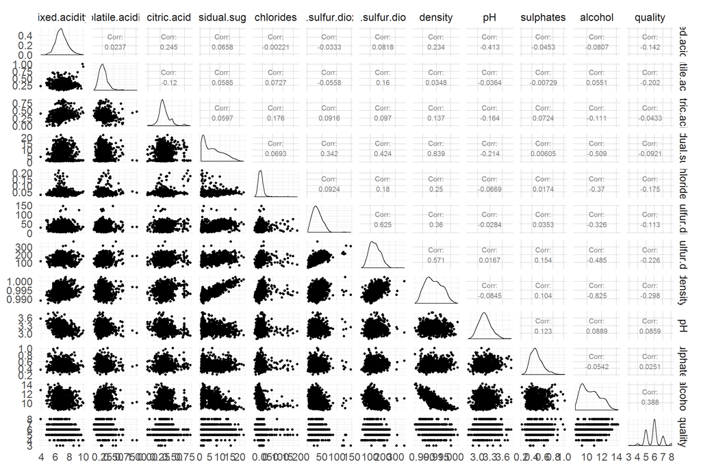

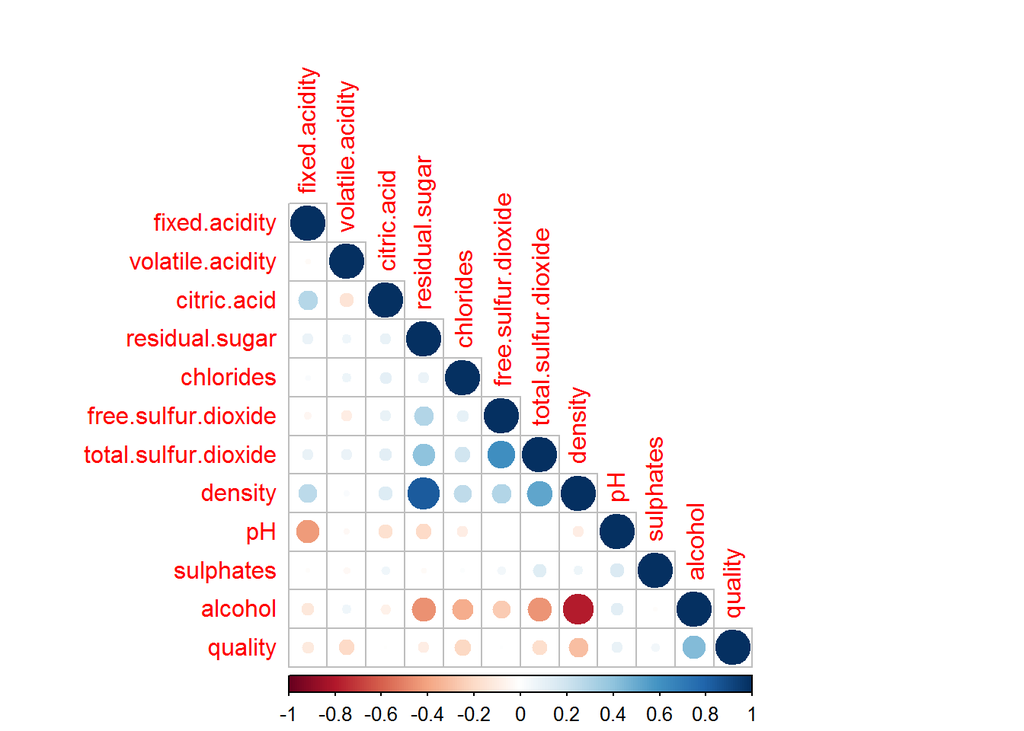

##### Findinds from the scatterplot matrices

1. PH & fixed.acidity –>Negative correlation
2. Density & quality –>Negative correlation
3. Density & Alcohol –>Negative correlation
4. Density & residual.sugar –>Positive correlation,etc.
5. residual.sugar & alcohol –>Negative correlation

#### Alcohol and Quality

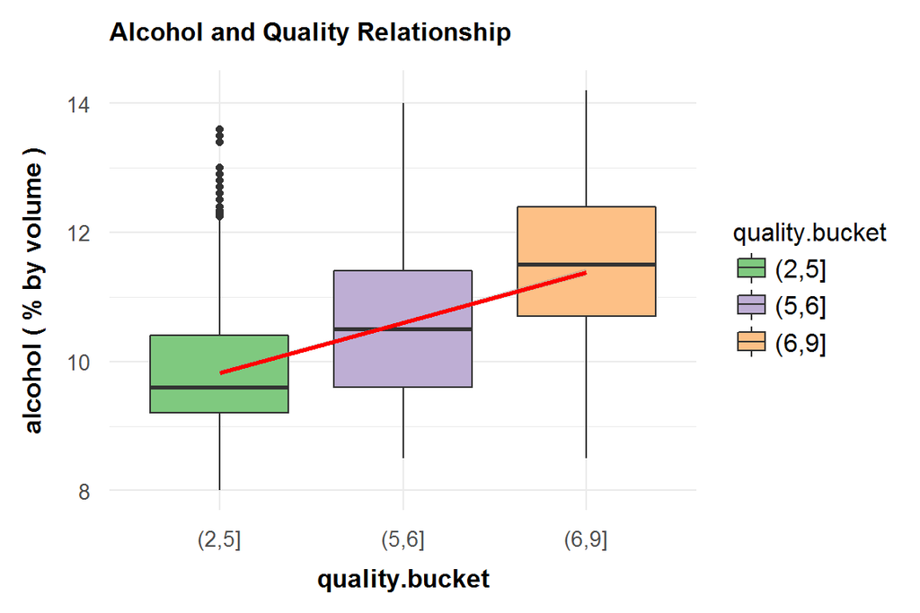

##### Instead analyzing the quality on all levels, I will create a new variables and cut the quality into 3 range.

#### Density and Quality

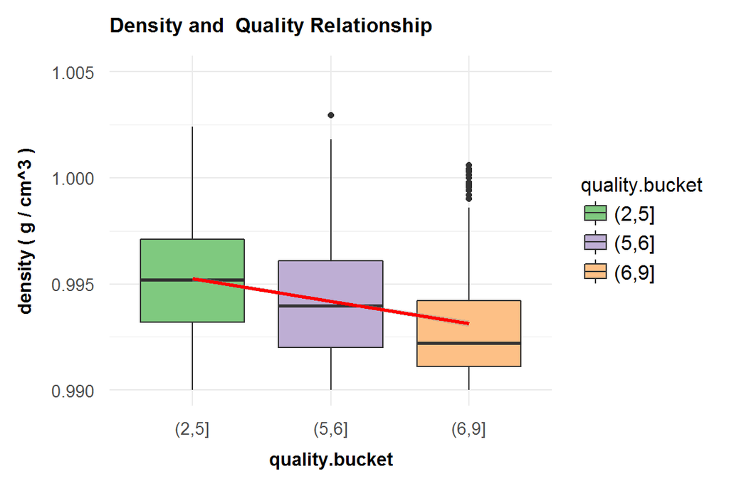

```
##
##  Pearson's product-moment correlation
##
## data:  wine$density and wine$quality
## t = -22.581, df = 4896, p-value < 2.2e-16
## alternative hypothesis: true correlation is not equal to 0
## 95 percent confidence interval:
##  -0.3322718 -0.2815385
## sample estimates:
##        cor
## -0.3071233
```

#### Density and Alcohol

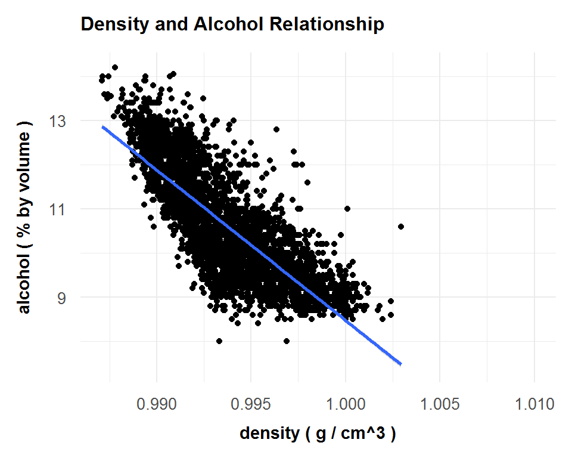

```
##
##  Pearson's product-moment correlation
##
## data:  wine$density and wine$alcohol
## t = -87.255, df = 4896, p-value < 2.2e-16
## alternative hypothesis: true correlation is not equal to 0
## 95 percent confidence interval:
##  -0.7908646 -0.7689315
## sample estimates:
##        cor
## -0.7801376
```

#### Density and residual.sugar

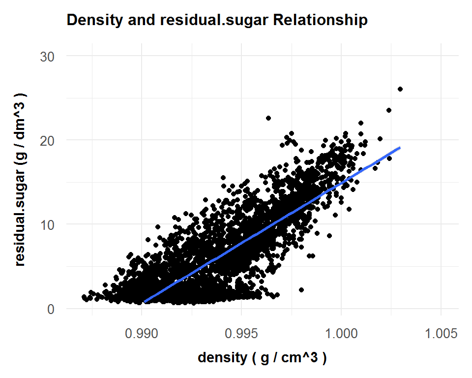

```
##
##  Pearson's product-moment correlation
##
## data:  wine$density and wine$residual.sugar
## t = 107.87, df = 4896, p-value < 2.2e-16
## alternative hypothesis: true correlation is not equal to 0
## 95 percent confidence interval:
##  0.8304732 0.8470698
## sample estimates:
##       cor
## 0.8389665
```

#### Density and total.sulfur.dioxide

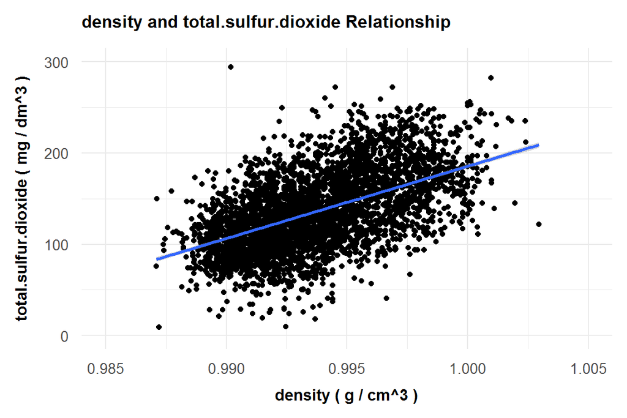

```
##
##  Pearson's product-moment correlation
##
## data:  wine$density and wine$total.sulfur.dioxide
## t = 43.719, df = 4896, p-value < 2.2e-16
## alternative hypothesis: true correlation is not equal to 0
## 95 percent confidence interval:
##  0.5094349 0.5497297
## sample estimates:
##       cor
## 0.5298813
```

#### pH and fixed.acidity

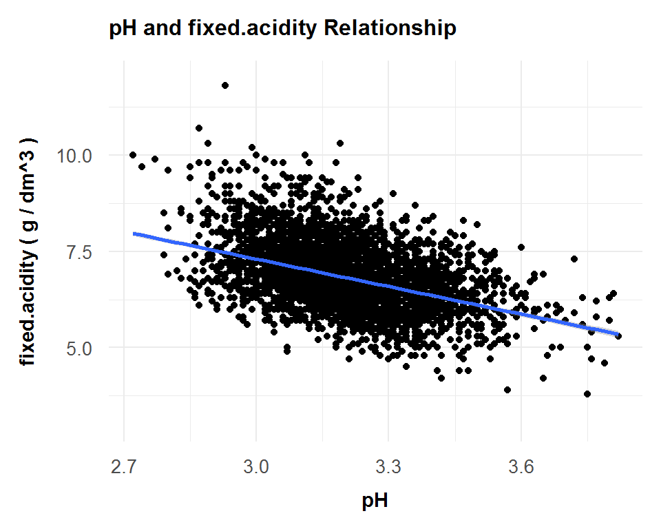

```
##
##  Pearson's product-moment correlation
##
## data:  wine$pH and wine$fixed.acidity
## t = -32.934, df = 4896, p-value < 2.2e-16
## alternative hypothesis: true correlation is not equal to 0
## 95 percent confidence interval:
##  -0.4485154 -0.4026542
## sample estimates:
##        cor
## -0.4258583
```

#### **Multivariate Plots Section**

#### Density & Alcohol & Wine Quality

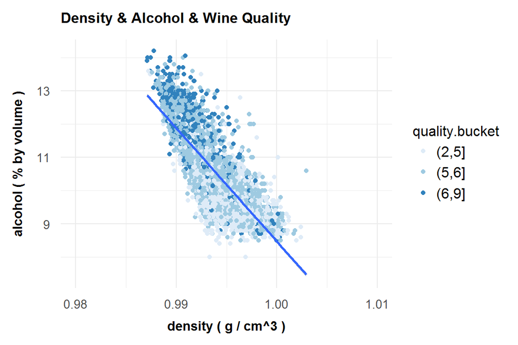

1. From the graph we can see, higher quality wine tends to have high alcohol and lower density.
2. With same density, higher quality wine tends to have higher alcohol.
3. Also we can find the negative correlation between alcohol and density.

#### Density & Sugar & Wine Quality

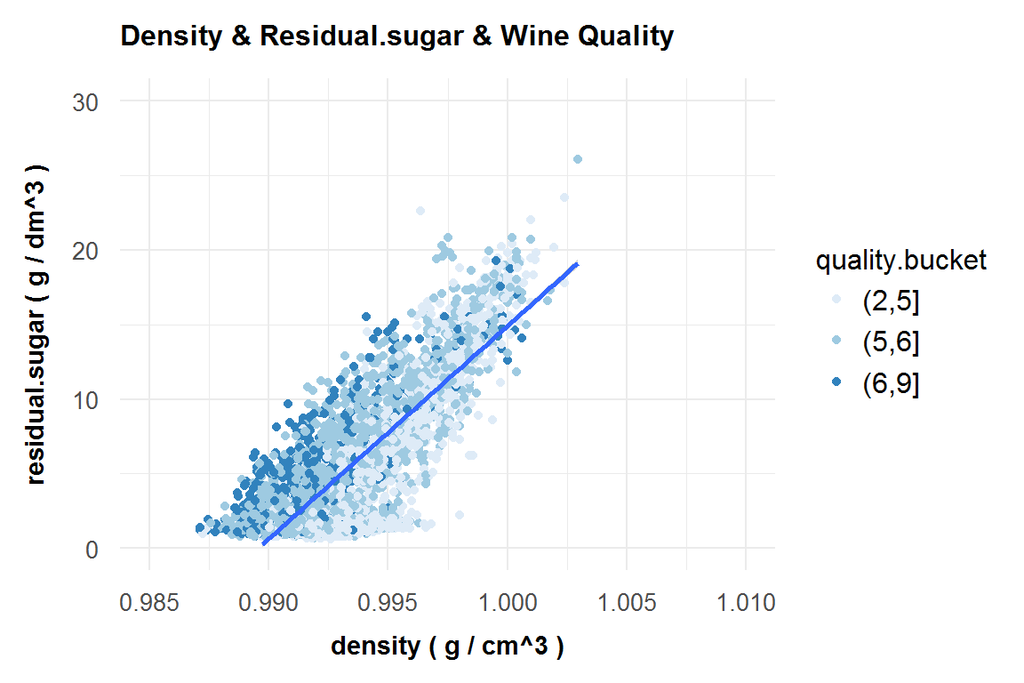

1. From the graph we can see, higher quality wine tends to have lower residual.sugar and lower density.
2. With same density, higher quality wine tends to have higher residual.sugar
3. Also we can find the positive correlation between residual.sugar and density.

#### Density & total.sulfur.dioxide & Wine Quality

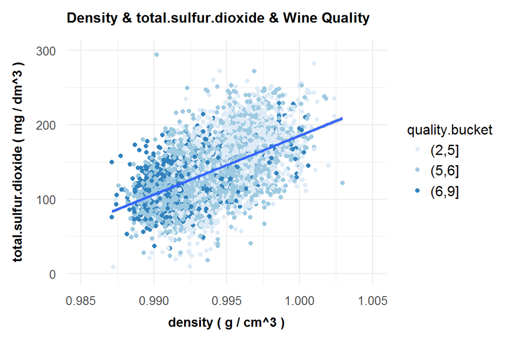

#### Density & residual.sugar & alcohol

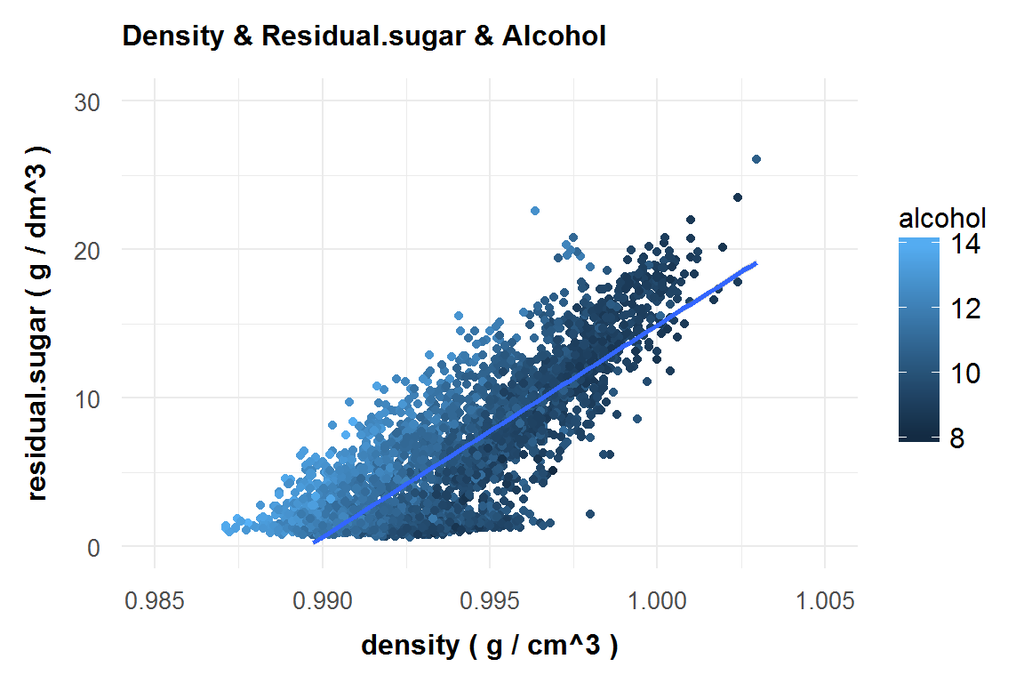

#### linear regression

```r
#####linear regression
quality_linear = lm(formula = quality~. , data = wine_samp)
quality_linear
```

```
##
## Call:
## lm(formula = quality ~ ., data = wine_samp)
##
## Coefficients:
##          (Intercept)         fixed.acidity      volatile.acidity
##            1.502e+02             6.552e-02            -1.863e+00
##          citric.acid        residual.sugar             chlorides
##            2.209e-02             8.148e-02            -2.473e-01
##  free.sulfur.dioxide  total.sulfur.dioxide               density
##            3.733e-03            -2.857e-04            -1.503e+02
##                   pH             sulphates               alcohol
##            6.863e-01             6.315e-01             1.935e-01
```

```r
summary(quality_linear)
```

```
##
## Call:
## lm(formula = quality ~ ., data = wine_samp)
##
## Residuals:
##     Min      1Q  Median      3Q     Max
## -3.8348 -0.4934 -0.0379  0.4637  3.1143
##
## Coefficients:
##                        Estimate Std. Error t value Pr(>|t|)
## (Intercept)           1.502e+02  1.880e+01   7.987 1.71e-15 ***
## fixed.acidity         6.552e-02  2.087e-02   3.139  0.00171 **
## volatile.acidity     -1.863e+00  1.138e-01 -16.373  < 2e-16 ***
## citric.acid           2.209e-02  9.577e-02   0.231  0.81759
## residual.sugar        8.148e-02  7.527e-03  10.825  < 2e-16 ***
## chlorides            -2.473e-01  5.465e-01  -0.452  0.65097
## free.sulfur.dioxide   3.733e-03  8.441e-04   4.422 9.99e-06 ***
## total.sulfur.dioxide -2.857e-04  3.781e-04  -0.756  0.44979
## density              -1.503e+02  1.907e+01  -7.879 4.04e-15 ***
## pH                    6.863e-01  1.054e-01   6.513 8.10e-11 ***
## sulphates             6.315e-01  1.004e-01   6.291 3.44e-10 ***
## alcohol               1.935e-01  2.422e-02   7.988 1.70e-15 ***
## ---
## Signif. codes:  0 '***' 0.001 '**' 0.01 '*' 0.05 '.' 0.1 ' ' 1
##
## Residual standard error: 0.7514 on 4886 degrees of freedom
## Multiple R-squared:  0.2819, Adjusted R-squared:  0.2803
## F-statistic: 174.3 on 11 and 4886 DF,  p-value: < 2.2e-16
```

##### Due to the correlations between several independent variables (multicollinearity), the linear models doesn’t provide accurate results, the adjusted R-squared is small also.

#### **Final Plots and Summary**

#### Plot One - “Alcohol by quality”

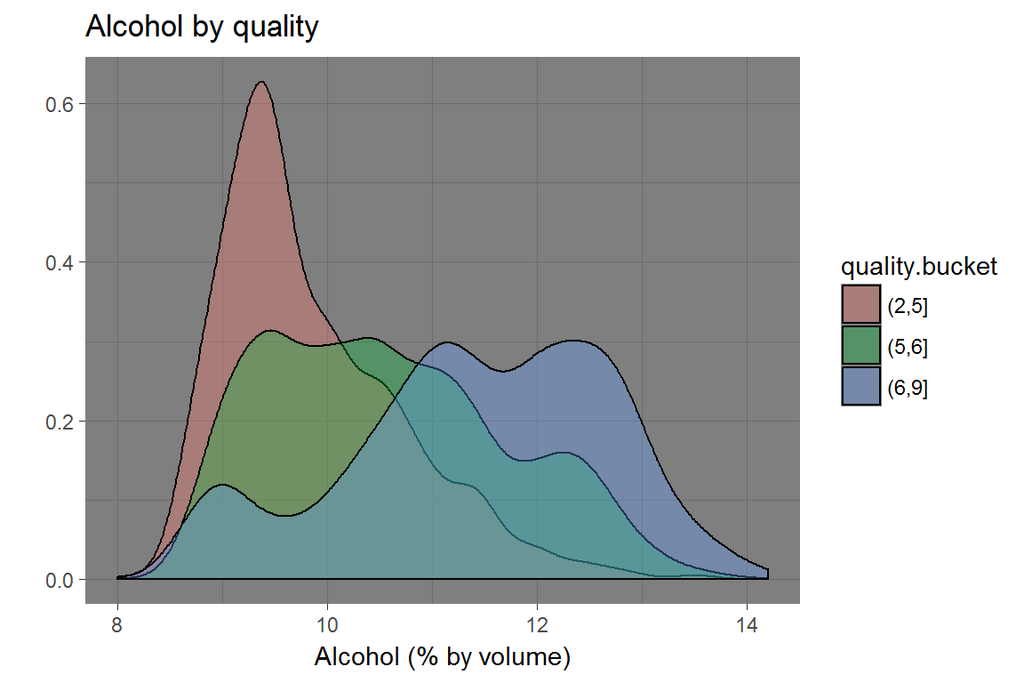

##### Description One

From the density plot we can see the relationship between wine quality and alcohol. Higher quality wine has more alcohol.

#### Plot Two - “Density by quality”

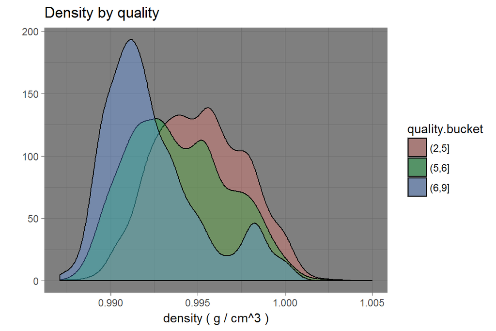

##### Description Two

From the density plot we can see the relationship between wine quality and density, Higher quality wine tends to have less density.

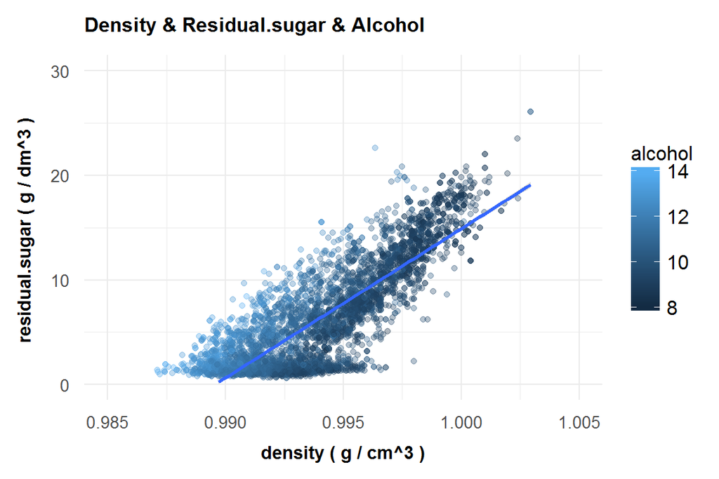

#### Description Three

##### We’ve also found some interesting relationship between residual sugar, density and alcohol: sweater wine has more density and wine with the same sweetness has larger volume of alcohol with lower density.

##### Reflection

1. Good wine tend to have more alcoho, probably because alcohol kills more residual.sugar or SO2.
2. Good wine tend to have lower density, probably because lower density has lower residual.sugar or SO2.
3. I hope I can take more courses and build a more accurate model to predict the wine quality.